# Amylase Binding Protein Reads from Superreference

## Set up

Set up

```r
library(tidyverse)
library(ggbeeswarm)
library(dabestr)
library(broom)
library(rcompanion)
```

Load genus/stats superrefernece stats (previously generated in notebook `031-supperferencemapped_stats`)

```r
superreference_data <- read_tsv("../04-analysis/deep/competitive_mapping.backup/superreference_mapping_statistics_raw_20190522.tsv.gz")
raw_metadata_deep <- read_tsv("../00-documentation.backup/17-Deep_Sequencing_HumanFiltering_Results_20200220.tsv")
abp_data <- Sys.glob("../04-analysis/deep/eager/superreference_mapping/output/Streptococcus/*/5-DeDup/") %>%
  list.files("*reads.tsv.gz", full.names = T) %>%
  enframe(name = NULL, value = "file_path") %>%
  mutate(file_contents = map(file_path, ~read_tsv(.x,
                                                  col_names = c("chrom", "start_coordinate", "end_coordinate", "name", "reads"),
                                                  col_types = cols("c", "d", "d", "c", "d"))),
         individual = map(file_path, ~str_split(.x, "/") %>% unlist() %>% tail(n = 4) %>% head(n = 1)) %>% unlist,
         abp_type = map(file_path, ~ basename(.x) %>%
                          str_split("_") %>%
                          pluck(1,6) %>%
                          str_split("\\.") %>%
                          unlist %>%
                          pluck(4) %>%
                        str_replace("reads", "-like")) %>% unlist)
```

Set some ordering and aesthetics

```r
host_general_order <- c("ExtractionBlank", "LibraryBlank", "Howler", "Gorilla", "Chimp", "Neanderthal", "PreagriculturalHuman", "PreantibioticHuman", "ModernDayHuman")
host_genus_order <- c("Control", "Alouatta", "Gorilla", "Pan", "Homo")

common_colours <- c(`0` = "black", Alouatta = "#1f78b4", Gorilla = "#6a3d9a", Pan = "#33a02c",
          `Homo (Neanderthal)` = "#fdbf6f",
          `Homo (Modern Human)` = "#ff7f00", ExtractionControl = "#d9d9d9",
          LibraryControl = "#d9d9d9", Plaque = "#d9d9d9", Gut = "#d9d9d9",
          Skin = "#d9d9d9", Sediment = "#d9d9d9", EnvironmentalControl = "#d9d9d9")

common_shapes <- c(Alouatta = 8, Gorilla = 0, Pan = 1,
          `Homo (Neanderthal)` = 2, `Homo (Modern Human)` = 6,
          ExtractionControl = 3, LibraryControl = 7, Plaque = 9,
          Gut = 7, Skin = 14, Sediment = 10, EnvironmentalControl = 12)

 env_shapes <- c(8,
                0,
                1,
                2,
                0,
                1,
                2,
                5,
                11,
                0,
                12,
                1,
                10,
                2,
                6,
                10,
                13,
                7,
                8,
                14,
                3,
                4,
                12,
                0)

names(env_shapes) <- c("Howler_Monkey",
           "Gorilla_1",
           "Gorilla_2",
           "Gorilla_3",
           "Chimp_1",
           "Chimp_2",
           "Chimp_3",
           "Chimp_4",
           "Neanderthal",
           "PreagriculturalHuman_1",
           "PreagriculturalHuman_2",
           "PreantibioticHuman_1",
           "PreantibioticHuman_2",
           "ModernDayHuman_1",
           "ModernDayHuman_2",
           "ExtractionControl",
           "LibraryControl",
           "ruralGut",
           "sediment",
           "skin",
           "subPlaque",
           "supPlaque",
           "urbanGut",
           "EnvironmentalControl")
```

## Calculations

Get total Streptococcus super-reference reads.

```r
## Collapse the contigs
superreference_data_meta <- superreference_data %>%
  group_by(genus, sample, species) %>%
  summarise(total_no_reads = sum(no_reads),
             total_no_bases_covered = sum(no_bases_covered),
             total_species_length = sum(feature_length),
             mean_mean_depth_coverage = mean(mean_depth_coverage)
             ) %>%
    mutate(percent_covered = (total_no_bases_covered / total_species_length) * 100) %>%
  group_by(sample) %>%
  mutate(total_dataset_reads = sum(total_no_reads)) %>%
  left_join(raw_metadata_deep %>%
              select(sample_name, Env, Description, Host_General,
                     Host_Genus, Host_Common, Age, total_unmapped_reads),
            by = c("sample" = "sample_name")
            ) %>%
    filter(Host_Genus != "Control")

superreference_data_total <- superreference_data_meta %>%
  filter(genus == "Streptococcus") %>%
  group_by(sample) %>%
  summarise(total_genus_reads = sum(total_no_reads)) %>%
  rename(individual = sample)
```

Now clean up abp reads and calculate sums per sample and gene

```r
abp_data_clean <- abp_data %>%
  select(individual, abp_type, file_contents) %>%
  unnest() %>%
  group_by(individual, abp_type) %>%
  summarise(total_abp_reads = sum(reads))
```

```
`cols` is now required.
Please use `cols = c(file_contents)`
```

Join together

```r
data_combined <- left_join(superreference_data_total, abp_data_clean) %>%
  mutate(`Ratio of abp-associated reads to total Streptococcus reads` = total_abp_reads / total_genus_reads) %>%
  rename(Individual = individual,
         )
```

Set ordering

```r
data_combined <- data_combined %>%
  mutate(Group = if_else(grepl("DJA|EBO|KNP|MTM|OME", Individual), "Primate", "Non-Primate"),
         Group = factor(Group, levels = c("Primate", "Non-Primate"))) %>%
  left_join(raw_metadata_deep, by = c("Individual" = "sample_name")) %>%
  mutate(Env = factor(Env, levels = names(env_shapes)),
         Host_Common = factor(Host_Common, levels = names(common_shapes))) %>%
  arrange(Env) %>%
  mutate(Individual = as_factor(Individual))
```

To save

```r
## And save
write_tsv(data_combined, "../04-analysis/deep/streptococcus_investigation.backup/Streptococcus_superreference_amylaseReadsOverAllReads_rawdata.tsv")
```

## Plotting

And plot

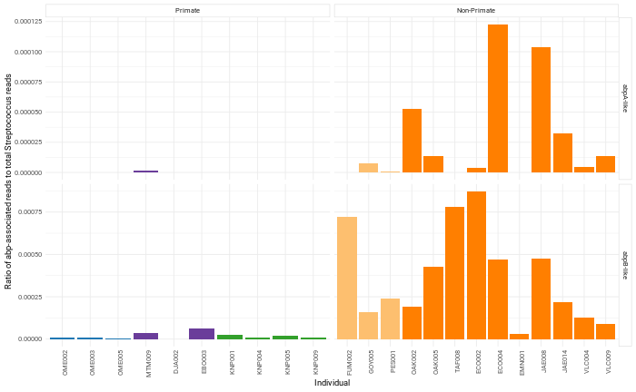

```r
final_plot <- ggplot(data_combined, aes(Individual, `Ratio of abp-associated reads to total Streptococcus reads`, fill = Host_Common)) +
  geom_bar(stat = "identity") +
  scale_fill_manual(values = common_colours) +
  facet_grid(abp_type ~ Group, scales = "free") +
  theme_minimal(base_size = 7, base_family = "Roboto") +
  theme(axis.text.x = element_text(angle = 90, hjust = 1),
        strip.background = element_rect(colour = "lightgrey"),
        legend.position = "none")

final_plot
```

to save

```r
ggsave(plot = final_plot,
       "../04-analysis/deep/streptococcus_investigation.backup/Streptococcus_superreference_amylaseReadsOverAllReads_plot.pdf",
      device = cairo_pdf,
      width = 3.5,
      height = 3.5,
      units = "in",
      dpi = 600)
```

Or

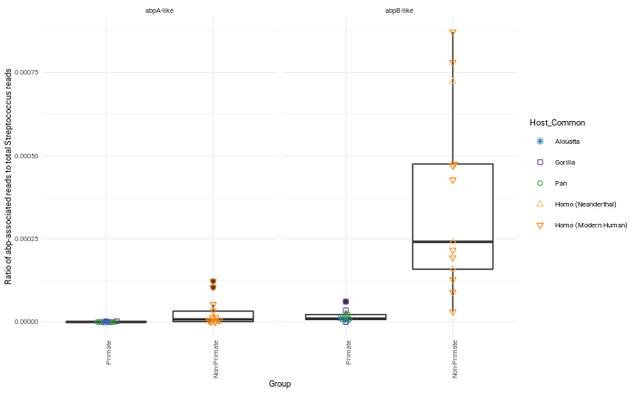

```r
ggplot(data_combined, aes(Group, `Ratio of abp-associated reads to total Streptococcus reads`)) +
  geom_boxplot() +
  geom_beeswarm(aes(fill = Host_Common, colour = Host_Common, shape = Host_Common)) +
  scale_fill_manual(values = common_colours) +
  scale_shape_manual(values = common_shapes) +
  scale_colour_manual(values = common_colours) +
  facet_grid(~ abp_type, scales = "free_x") +
  theme_minimal(base_size = 7, base_family = "Roboto") +
  theme(axis.text.x = element_text(angle = 90, hjust = 1))
```

## Statistical Testing

To verify the differences betwen *Homo* and non- *Homo*, we want to work out which statistical tests we could apply. For this we first need to see if the data is normally distributed.

Firstly we can make a reduced data tibble.

```r
data_reduced <- data_combined %>% mutate(Group = case_when(
  Group == "Primate" ~ "Non-Homo",
  Group == "Non-Primate" ~ "Homo",
  TRUE ~ NA_character_
)) %>% select(Individual, Group, abp_type, `Ratio of abp-associated reads to total Streptococcus reads`, Host_Common)
```

As an overall visualisation, we can make a Gardner-Altman plot as implemented with the `dabestr` package.

```r
data_reduced <- data_reduced %>% group_split(abp_type)

names(data_reduced) <- unique(data_combined$abp_type)
```

Now we can run the dabest function.

```r
dabestr_result_A <- dabest(data_reduced$`abpA-like`,
       Group,`Ratio of abp-associated reads to total Streptococcus reads`,
       idx = c("Non-Homo", "Homo"),
       paired = FALSE)

dabestr_result_B <- dabest(data_reduced$`abpB-like`,
       Group,`Ratio of abp-associated reads to total Streptococcus reads`,
       idx = c("Non-Homo", "Homo"),
       paired = FALSE)

dabestr_result_A
```

[output not shown]

```r
dabestr_result_B
```

[output not shown]

To visualise

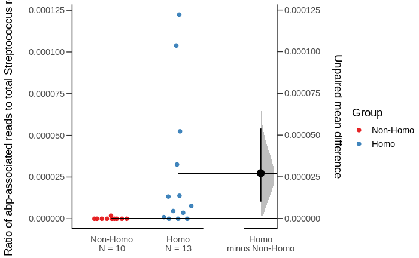

```r
plot(dabestr_result_A, color.column = Group)
```

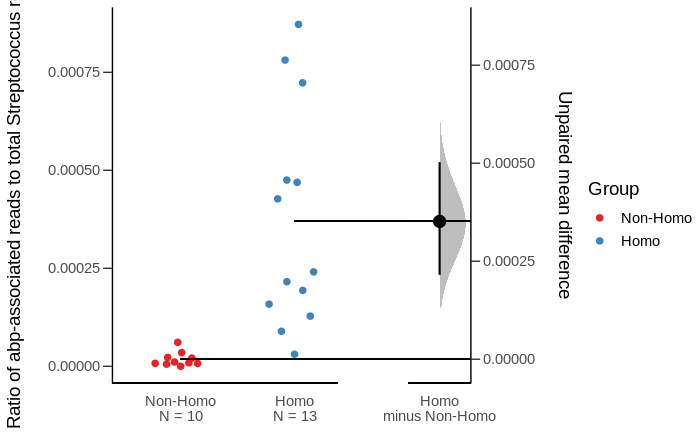

```r
plot(dabestr_result_B, color.column = Group)
```

However, we don’t have normally distributed data so many the G-A plots aren’t the best.

Instead, we can perform a Mann-Whitney U test as a non-parametric test that sampling between two independent populations will likely result as being greater or lower between the two populations.

We match the assumptions that: observations between the groups are independent, we have orddinal data, null hypothesis is the distributions are equal, and alternate is not-equal.

To do this in R:

```r
## Base R
result_mwu_abpA <- wilcox.test(data = data_reduced$`abpA-like`, `Ratio of abp-associated reads to total Streptococcus reads` ~ Group) %>%
  broom::tidy() %>%
  mutate(abp_type = "abpA")
```

```
cannot compute exact p-value with ties
```

```r
result_mwu_abpB <- wilcox.test(data = data_reduced$`abpB-like`, `Ratio of abp-associated reads to total Streptococcus reads` ~ Group) %>%
  broom::tidy() %>%
  mutate(abp_type = "abpB")

## combined

result_mwu_abp <- bind_rows(result_mwu_abpA, result_mwu_abpB)
```

These are relatively well supported results, as a Mann-whitney U test interally does a form of permutation (if I understand it correctly), as it essentially looks how many times each sample in one group is higher than each sampele in the other. In both cases we have large statistic values and *p* -values of much less than an alpha 0.05

We should also check the effect size, and the precision of the estimation. Here we use the statistic r (which is the Z-value divded by number of sample points), and then a confidence interval (at 95%)

```r
# With Coin
rcompanion::wilcoxonR( data_reduced$`abpA-like`$`Ratio of abp-associated reads to total Streptococcus reads`,  data_reduced$`abpA-like`$Group, ci = T)
```

|  | r | lower.ci | upper.ci |
| --- | --- | --- | --- |
| 1 | 0.663 | 0.415 | 0.88 |

```r
rcompanion::wilcoxonR( data_reduced$`abpB-like`$`Ratio of abp-associated reads to total Streptococcus reads`,  data_reduced$`abpB-like`$Group, ci = T)
```

|  | r | lower.ci | upper.ci |
| --- | --- | --- | --- |
| 1 | 0.815 | 0.69 | 0.851 |

```r
NA
```

For abpA, we have a fairly large effect size, but quite a broad CI. In contrast, abpB we have an even larger effect size, but with a tighter (presumably more precise), if skewed CI. However note that the broad CIs could be due to our small sample size.

To further check the robustness of the results, we can try a randomisation procedure, where we repeatedley shuffle all the group assignments, and each time to run the test. We expect to see that our result doesn’t fall in the distribution of the results of the shuffled data, the latter of which would hopefully be reflecting noise.

```r
## For abpA
bootstrap_abp_mwu <- NULL

for (i in 1:100) {
    shuffled_data = data_reduced$`abpA-like`
    shuffled_data$Group <- sample(shuffled_data$Group)
    result <- wilcox.test(data = shuffled_data, `Ratio of abp-associated reads to total Streptococcus reads` ~ Group) %>%
      broom::tidy() %>%
      mutate(abp_type = "abpA")
    bootstrap_abp_mwu <- bind_rows(bootstrap_abp_mwu, result)
}
```

[output not shown]

```r
for (i in 1:100) {
    shuffled_data = data_reduced$`abpB-like`
    shuffled_data$Group <- sample(shuffled_data$Group)
    result <- wilcox.test(data = shuffled_data, `Ratio of abp-associated reads to total Streptococcus reads` ~ Group) %>%
      broom::tidy() %>%
      mutate(abp_type = "abpB")
    bootstrap_abp_mwu <- bind_rows(bootstrap_abp_mwu, result)
}
```

Now we can plot the distributions, with our true result (with the right sample groupings assigned) indicated.

[figure not shown]

```r
ggsave(plot = abp_mwu_bootstrap,
       "../04-analysis/deep/streptococcus_investigation.backup/Streptococcus_superreference_abpratios_mwu_100randomshuffle_comparison.pdf",
      device = cairo_pdf,
      width = 3.5,
      height = 3.5,
      units = "in",
      dpi = 600)

ggsave(plot = abp_mwu_bootstrap,
       "../04-analysis/deep/streptococcus_investigation.backup/Streptococcus_superreference_abpratios_mwu_100randomshuffle_comparison.png",
      device = "png",
      width = 3.5,
      height = 3.5,
      units = "in",
      dpi = 600)
```

Same for the statistic

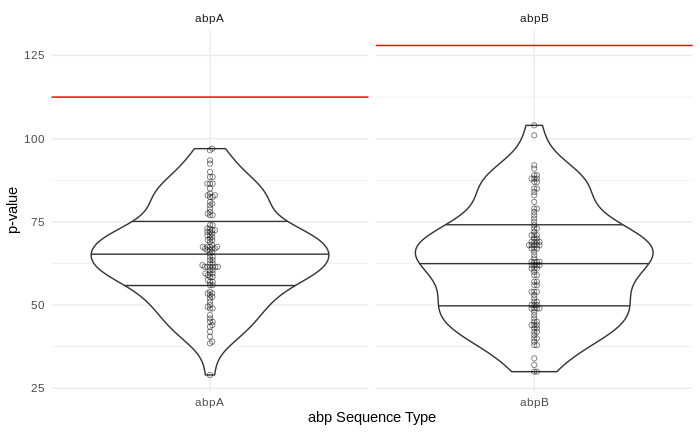

```r
abp_mwu_bootstrap <- ggplot(bootstrap_abp_mwu, aes(abp_type, statistic)) +
  geom_violin(draw_quantiles = c(0.25, 0.5, 0.75)) +
  geom_beeswarm(pch = 21, alpha = 0.5) +
  geom_hline(data = result_mwu_abp, aes(yintercept = statistic), colour = "red") +
  theme_minimal() +
  ylab("p-value") +
  xlab("abp Sequence Type") +
  facet_wrap(~ abp_type, scales = "free_x")

abp_mwu_bootstrap
```